# Week4_Notes

February 13, 2016

## PCA

- This week we will work with a statistical tool called principal component analysis.

## What is it?

is a statistical procedure that uses an orthogonal transformation to convert a set of observations of possibly correlated variables into a set of values of linearly uncorrelated variables called principal components.

Before we get into it, lets introduce the various topics

## Covariance

- Standard deviation and variance only operate on 1 dimension, so that you could only calculate the standard deviation for each dimension of the data set independently of the other dimensions.
- However, it is useful to have a similar measure to find out how much the dimensions vary from the mean with respect to each other
- Covariance is such a measure. Covariance is always measured between 2 dimensions. If you calculate the covariance between one dimension and itself, you get the variance.

## Covariance (part 2)

- So, if you had a 3-dimensional data set \((x, y, z)\), then you could measure the covariance between the x and y dimensions, the x and z dimensions, and the y and z dimensions. Measuring the covariance between x and x, or y and y, or z and z would give you the variance of the x, y and z dimensions respectively.

## Covariance (part 3)

The formula for covariance is very similar to the formula for variance. The formula for variance could also be written like this: \[ var(X) = \frac{\sum_{i=1}^n(X_i-\bar{X})(X_i-\bar{X})}{n-1} \]

where I have simply expanded the square term to show both parts. So given that knowledge, here is the formula for covariance:

\[ COV(X) = \frac{\sum_{i=1}^n(X_i-\bar{X})(Y_i-\bar{Y})}{n-1} \]

## Covariance Matrix

A useful way to get all the possible covariance values between all the different dimensions is to calculate them all and put them in a matrix. So, the definition for the covariance matrix for a set of data with \(n\) dimensions is: \[ C^{n\times n} = (c_{ij},c_{ij} = cov(DIM_i,DIM_j)) \]

where \(C^{n\times n}\) is a matrix with \(n\) rows and \(n\) columns, and \(DIM_x\) is the \(x^{th}\) dimension.

## Covariance Matrix Example

3 dimensional covariance matrix \[ C = \left( \begin{array}{ccc} cov(x,x) & cov(x,y) & cov(x,z) \\ cov(y,x) & cov(y,y) & cov(y,z) \\ cov(z,x) & cov(z,y) & cov(z,z) \end{array} \right) \]

Notice the matrix is symmetrical about the diagonal. Why?

## Covariance Example

Calculate covariance between x and y

| x | y |
| --- | --- |
| 10 | 43 |
| 39 | 13 |
| 19 | 32 |
| 23 | 21 |
| 28 | 20 |

## Covariance Example (part 2)

Mean of x = 23.8, Mean of y = 25.8 \[ \begin{align} COV(X) & = \frac{\sum_{i=1}^n(X_i-\bar{X})(Y_i-\bar{Y})}{n-1} \\ & = \frac{(-13.8)(17.2) + (15.2)(-12.8) + (-4.8)(6.2) + (-0.8)(-4.8) + (4.2)(-5.8)}{5-1} \\ & = \frac{-237.36 + -194.56 + -29.76 + 3.84 + -24.36}{4} \\ & = \frac{-482.2}{4} = -120.55 \end{align} \]

## Covariance Example (part 3)

or we can do

```r
x=c(10,39,19,23,28)
y=c(43,13,32,21,20)
cov(x,y)
```

```
## [1] -120.55
```

## Matrix Multiplication

Example of one non-eigenvector and one eigenvector.

\[ \left( \begin{array}{cc} 2 & 3 \\ 2 & 1 \end{array} \right) \times \left( \begin{array}{cc} 1 \\ 3 \end{array} \right) =\left( \begin{array}{cc} 11 \\ 5 \end{array} \right) \] and \[ \left( \begin{array}{cc} 2 & 3 \\ 2 & 1 \end{array} \right) \times \left( \begin{array}{cc} 3 \\ 2 \end{array} \right) =\left( \begin{array}{cc} 12 \\ 8 \end{array} \right) =4\left( \begin{array}{cc} 3 \\ 2 \end{array} \right) \]

## Matrix Multiplication (part 2)

How a scaled eigenvector is still and eigenvector \[ 2 \times \left( \begin{array}{cc} 3 \\ 2 \end{array} \right) =\left( \begin{array}{cc} 6 \\ 4 \end{array} \right) \] \[ \left( \begin{array}{cc} 2 & 3 \\ 2 & 1 \end{array} \right) \times \left( \begin{array}{cc} 6 \\ 4 \end{array} \right) =\left( \begin{array}{cc} 24 \\ 16 \end{array} \right) = 4\left( \begin{array}{cc} 6 \\ 4 \end{array} \right) \]

## Eigenvectors

- As you know, you can multiply two matrices together, provided they are compatible sizes.
- Eigenvectors are a special case of this. Consider the two multiplications between a matrix and a vector in the first matrix example

## Eigenvectors (part 2)

- In the first example, the resulting vector is not an integer multiple of the original vector, whereas in the second example, the example is exactly 4 times the vector we began with.
- Why is this? Well, the vector is a vector in 2 dimensional space. The vector [3 2] (from the second example multiplication) represents an arrow pointing from the origin. The other matrix, the square one, can be thought of as a transformation matrix.

## Properties of Eigenvectors

You should first know that eigenvectors can only be found for square matrices. And, not every square matrix has eigenvectors. And, given an \(n\times n\) matrix that does have eigenvectors, there are \(n\) of them. Given a \(3\times 3\) matrix, there are 3 eigenvectors.

Another property of eigenvectors is that even if I scale the vector by some amount before I multiply it, I still get the same multiple of it as a result.

Lastly, all the eigenvectors of a matrix are perpendicular, ie. at right angles to each other, no matter how many dimensions you have i.e. orthogonal.

## Eigenvectors (part 3)

- Lastly, all the eigenvectors of a matrix are perpendicular, ie. at right angles to each other, no matter how many dimensions you have i.e. orthogonal.
- This is important because it means that you can express the data in terms of these perpendicular eigenvectors, instead of expressing them in terms of the \(x\) and \(y\) axes. We will be doing this later in the section on PCA.
- Often times, eigenvectors are normalized so their length is one.

## Finding Eigenvectors

How does one go about finding these mystical eigenvectors? Unfortunately, it’s only easy(ish) if you have a rather small matrix, like no bigger than about \(3\times 3\).

- The usual way to find the eigenvectors is by complicated iterative methods, which are sometimes neccesary.

## Eigenvalues

Eigenvectors and eigenvalues always come in pairs.

## Principal Components Analysis

- It is a way of identifying patterns in data, and expressing the data in such a way as to highlight their similarities and differences
- Since patterns in data can be hard to find in data of high dimension, where the luxury of graphical representation is not available, PCA is a powerful tool for analysing data

## PCA Method Part 1: Substract the mean

For PCA to work properly, you have to subtract the mean from each of the data dimensions. The mean subtracted is the average across each dimension. So, all the \(x\) values have \(\bar{x}\) (the mean of \(x\)) subtracted and all the \(y\) values subtracted from \(\bar{y}\).

This produces a data set whose mean is zero.

## PCA Method Part 2: Calculate the covariance matrix

We can do this by doing what we did in a previous section before

## PCA Part 3: Calculate the eigenvectors and eigenvalues of the covariance matrix

- Since the covariance matrix is square, we can calculate the eigenvectors and eigenvalues for this matrix. These are rather important, as they tell us useful information about our data.

## PCA Part 4: Choosing components and forming a feature vector

Here is where the notion of data compression and reduced dimensionality comes into it.

In fact, it turns out that the eigenvector with the highest eigenvalue is the principle component of the data set.

In general, once eigenvectors are found from the covariance matrix, the next step is to order them by eigenvalue, highest to lowest. This gives you the components in order of significance.

Now, if you like, you can decide to ignore the components of lesser significance. You do lose some information, but if the eigenvalues are small, you don’t lose much.

## PCA Part 4: Choosing components and forming a feature vector

What needs to be done now is you need to form a feature vector, which is just a fancy name for a matrix of vectors. This is constructed by taking the eigenvectors that you want to keep from the list of eigenvectors, and forming a matrix with these eigenvectors in the columns

\[ FeatureVector = (eig_1\,eig_2\,...\,eig_n) \]

## PCA Part 5: Choosing components and forming a feature vector

Once we have chosen the components (eigenvectors) that we wish to keep in our data and formed a feature vector, we simply take the transpose of the vector and multiply it on the left of the original data set, transposed.

\[ FinalData = RowFeatureData\times RowDataAdjust \]

where \(RowFeatureData\) is the matrix with the eigenvectors in the columns tranposed so that the eigenvectors are now in the rows, with the more significant eigenvector at the top.

\(RowDataAdjust\) is the mean-adjusted data transposed.

## PCA Part 5: Choosing components and forming a feature vector

What will this give us? It will give us the original data solely in terms of the vectors we chose. This was why it was important that eigenvectors are always perpendicular to each other.

So what have we done here? Basically we have transformed our data so that is expressed in terms of the patterns between them, where the patterns are the lines that most closely describe the relationships between the data.

This is helpful because we have now classified our data point as a combination of the contributions from each of those lines. Initially we can have simple x and y axes. This is fine, but the x and y values of each data point don’t really tell us exactly how that point relates to the rest of the data.

In the case of the transformation using both eigenvectors, we have simply altered the data so that it is in terms of those eigenvectors instead of the usual axes.

## PCA Example in R

I will use the iris dataset for the demonstration. The data contain four continuous variables which corresponds to physical measures of flowers and a categorical variable describing the flowers’ species.

```r
# Load data
data(iris)
head(iris, 3)
```

```
##   Sepal.Length Sepal.Width Petal.Length Petal.Width Species
## 1          5.1         3.5          1.4         0.2  setosa
## 2          4.9         3.0          1.4         0.2  setosa
## 3          4.7         3.2          1.3         0.2  setosa
```

## PCA Example in R (part 2)

We will apply PCA to the four continuous variables and use the categorical variable to visualize the PCs later. Notice that in the following code we apply a log transformation to the continuous variables as suggested by:

http://tgmstat.wordpress.com/2013/11/28/computing-and-visualizing-pca-in-r/#ref1

And set center and scale. equal to TRUE in the call to prcomp to standardize the variables prior to the application of PCA:

## PCA Example in R (part 3)

```r
# log transform
log.ir <- log(iris[, 1:4])
ir.species <- iris[, 5]

# apply PCA - scale. = TRUE is highly
# advisable, but default is FALSE.
ir.pca <- prcomp(log.ir,
                 center = TRUE,
                 scale. = TRUE)
```

## PCA Example in R (part 4)

Since skewness and the magnitude of the variables influence the resulting PCs, it is good practice to apply skewness transformation, center and scale the variables prior to the application of PCA.

In the example above, we applied a log transformation to the variables but we could have been more general and applied a different transformation.

## PCA Example in R (part 5)

- The **prcomp** function returns an object of class prcomp, which have some methods available.
- The print method returns the standard deviation of each of the four PCs, and their rotation (or loadings), which are the coefficients of the linear combinations of the continuous variables.

## PCA Example in R (part 6)

```r
# print method
print(ir.pca)
```

```
## Standard deviations:
## [1] 1.7124583 0.9523797 0.3647029 0.1656840
##
## Rotation:
##                     PC1         PC2        PC3         PC4
## Sepal.Length  0.5038236 -0.45499872  0.7088547  0.19147575
## Sepal.Width  -0.3023682 -0.88914419 -0.3311628 -0.09125405
## Petal.Length  0.5767881 -0.03378802 -0.2192793 -0.78618732
## Petal.Width   0.5674952 -0.03545628 -0.5829003  0.58044745
```

## PCA Example in R (part 7)

- The plot method returns a plot of the variances (y-axis) associated with the PCs (x-axis). The Figure below is useful to decide how many PCs to retain for further analysis.
- In this simple case with only 4 PCs this is not a hard task and we can see that the first two PCs explain most of the variability in the data.

## PCA Example in R (part 8)

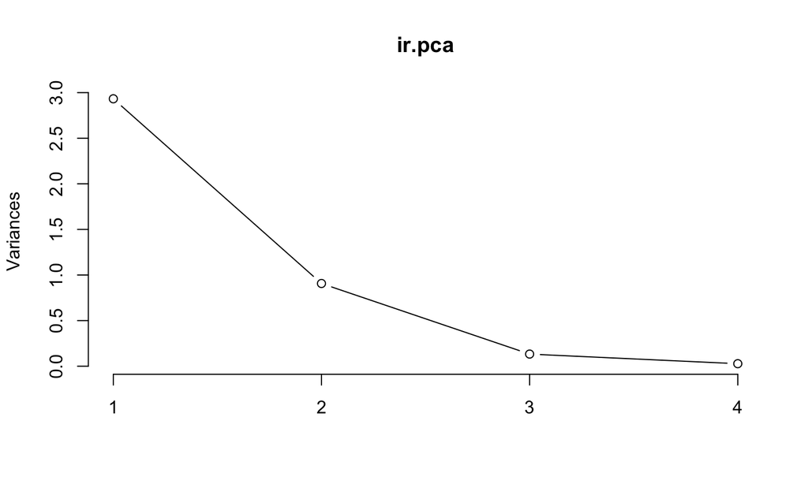

```r
# plot method
plot(ir.pca, type = "l")
```

## PCA Example in R (part 9)

```r
library(devtools)
install_github("ggbiplot", "vqv")
```

```
## Skipping install for github remote, the SHA1 (7325e880) has not changed since last install.
##   Use `force = TRUE` to force installation
```

```r
library(ggbiplot)
```

## PCA Example in R (part 10)

```r
plotPCA<-function(){
g <- ggbiplot(ir.pca, obs.scale = 1, var.scale = 1,
              groups = ir.species, ellipse = TRUE,
              circle = TRUE)
g <- g + scale_color_discrete(name = '')
g <- g + theme(legend.direction = 'horizontal',
               legend.position = 'top')
print(g)
}
```

## PCA Example in R (part 11)

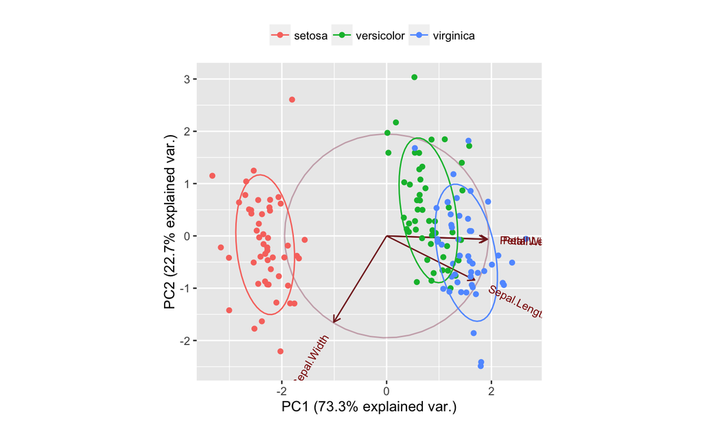

```r
plotPCA()
```

## Install Bioconductor and packages

```r
source("http://bioconductor.org/biocLite.R")
```

```
## Bioconductor version 3.2 (BiocInstaller 1.20.1), ?biocLite for help
```

```r
biocLite("gdsfmt")
```

```
## BioC_mirror: https://bioconductor.org
```

```
## Using Bioconductor 3.2 (BiocInstaller 1.20.1), R 3.2.3 (2015-12-10).
```

```
## Installing package(s) 'gdsfmt'
```

[output not shown]

```
## Old packages: 'curl', 'rmarkdown'
```

```r
biocLite("SNPRelate")
```

```
## BioC_mirror: https://bioconductor.org
```

```
## Using Bioconductor 3.2 (BiocInstaller 1.20.1), R 3.2.3 (2015-12-10).
```

```
## Installing package(s) 'SNPRelate'
```

[output not shown]

```
## Old packages: 'curl', 'rmarkdown'
```

```r
# Load the R packages: gdsfmt and SNPRelate
library(gdsfmt)
library(SNPRelate)
```

## PCA on vcf data (part 1)

```r
## Load our vcf data
vcf.fn <- system.file("extdata", "sequence.vcf", package="SNPRelate")
## we can also explictly load the data
## vcf.fn <- "C:/your_folder/your_vcf_file.vcf"
```

## PCA on vcf data (part 2)

```r
# Reformat
snpgdsVCF2GDS(vcf.fn, "test.gds", method="biallelic.only")
```

```
## VCF Format ==> SNP GDS Format
## Method: exacting biallelic SNPs
## Number of samples: 3
## Parsing "/Library/Frameworks/R.framework/Versions/3.2/Resources/library/SNPRelate/extdata/sequence.vcf" ...
##  import 2 variants.
## + genotype   { Bit2 3x2, 2 bytes } *
## Optimize the access efficiency ...
## Clean up the fragments of GDS file:
##  open the file "test.gds" (size: 2573)
##  # of fragments in total: 46
##  save it to "test.gds.tmp"
##  rename "test.gds.tmp" (size: 2261)
##  # of fragments in total: 20
```

```r
snpgdsSummary("test.gds")
```

```
## The file name: /Users/alexander.frieden/Documents/biostats/biostats_r_code/test.gds
## The total number of samples: 3
## The total number of SNPs: 2
## SNP genotypes are stored in SNP-major mode (Sample X SNP).
```

## PCA on vcf data (part 3)

```r
# Open the GDS file
genofile <- snpgdsOpen(snpgdsExampleFileName())
pop_code <- read.gdsn(index.gdsn(genofile, path="sample.annot/pop.group"))
table(pop_code)
```

```
## pop_code
## CEU HCB JPT YRI
##  92  47  47  93
```

## PCA on vcf data (part 4)

```r
# Display the first six values
head(pop_code)
```

```
## [1] "YRI" "YRI" "YRI" "YRI" "CEU" "CEU"
```

## HapMap populations

| Key | Description |
| --- | --- |
| ASW | African ancestry in Southwest USA |
| CEU | Utah residents with Northern and Western European ancestry from the CEPH collection |
| CHB | Han Chinese in Beijing, China |
| CHD | Chinese in Metropolitan Denver, Colorado |
| GIH | Gujarati Indians in Houston, Texas |
| JPT | Japanese in Tokyo, Japan |
| LWK | Luhya in Webuye, Kenya |
| MXL | Mexican ancestry in Los Angeles, California |

## HapMap populations (part 2)

| Key | Description |
| --- | --- |
| MKK | Maasai in Kinyawa, Kenya |
| TSI | Toscani in Italia |
| YRI | Yoruba in Ibadan, Nigeria |

## PCA on vcf data (part 5)

- It is suggested to use a pruned set of SNPs which are in approximate linkage equilibrium with each other to avoid the strong influence of SNP clusters in principal component analysis and relatedness analysis.
- Interesting paper relating to this here: https://cdr.lib.unc.edu/indexablecontent/uuid:0a68bb86-def4-4493-ae41-2d3228668b84
- This is called LD-based SNP pruning.

## PCA on vcf data (part 6)

```r
set.seed(1000)
# Try different LD thresholds for sensitivity analysis
snpset <- snpgdsLDpruning(genofile, ld.threshold=0.2)
```

```
## SNP pruning based on LD:
## Excluding 365 SNPs on non-autosomes
## Excluding 1 SNP (monomorphic: TRUE, < MAF: NaN, or > missing rate: NaN)
## Working space: 279 samples, 8722 SNPs
##  Using 1 (CPU) core
##  Sliding window: 500000 basepairs, Inf SNPs
##  |LD| threshold: 0.2
## Chromosome 1: 75.42%, 540/716
## Chromosome 2: 72.24%, 536/742
## Chromosome 3: 74.71%, 455/609
## Chromosome 4: 73.31%, 412/562
## Chromosome 5: 77.03%, 436/566
## Chromosome 6: 75.58%, 427/565
## Chromosome 7: 75.42%, 356/472
## Chromosome 8: 71.31%, 348/488
## Chromosome 9: 77.88%, 324/416
## Chromosome 10: 74.33%, 359/483
## Chromosome 11: 77.40%, 346/447
## Chromosome 12: 76.81%, 328/427
## Chromosome 13: 75.58%, 260/344
## Chromosome 14: 76.95%, 217/282
## Chromosome 15: 76.34%, 200/262
## Chromosome 16: 72.66%, 202/278
## Chromosome 17: 74.40%, 154/207
## Chromosome 18: 73.68%, 196/266
## Chromosome 19: 85.00%, 102/120
## Chromosome 20: 71.62%, 164/229
## Chromosome 21: 76.98%, 97/126
## Chromosome 22: 75.86%, 88/116
## 6547 SNPs are selected in total.
```

## PCA on vcf data (part 7)

Now we can see all the names of our snpset. Question: what do we not see here?

```r
names(snpset)
```

```
##  [1] "chr1"  "chr2"  "chr3"  "chr4"  "chr5"  "chr6"  "chr7"  "chr8"
##  [9] "chr9"  "chr10" "chr11" "chr12" "chr13" "chr14" "chr15" "chr16"
## [17] "chr17" "chr18" "chr19" "chr20" "chr21" "chr22"
```

```r
# Get all selected snp id
snpset.id <- unlist(snpset)
```

## PCA on vcf data (part 8)

The functions in SNPRelate for PCA include calculating the genetic covariance matrix from genotypes, computing the correlation coefficients between sample loadings and genotypes for each SNP, calculating SNP eigenvectors (loadings), and estimating the sample loadings of a new dataset from specified SNP eigenvectors.

## Quick review: Covariance matrix and covariance

## Review eigenvectors and eigenvalues

## PCA on vcf data (part 9)

```r
# Run PCA
pca <- snpgdsPCA(genofile, snp.id=snpset.id, num.thread=2)
```

```
## Principal Component Analysis (PCA) on SNP genotypes:
## Excluding 2541 SNPs on non-autosomes
## Excluding 0 SNP (monomorphic: TRUE, < MAF: NaN, or > missing rate: NaN)
## Working space: 279 samples, 6547 SNPs
##  Using 2 (CPU) cores
## PCA: the sum of all working genotypes (0, 1 and 2) = 1826801
## PCA: Mon Feb 22 18:30:46 2016    0%
## PCA: Mon Feb 22 18:30:46 2016    100%
## PCA: Mon Feb 22 18:30:46 2016    Begin (eigenvalues and eigenvectors)
## PCA: Mon Feb 22 18:30:46 2016    End (eigenvalues and eigenvectors)
```

## PCA on vcf data (part 10)

- The following codeshows how to calculate the percent of variation is accounted for by the top principal components.
- It is clear to see the first two eigenvectors hold the largest percentage of variance among the population, although the total variance accounted for is still less the one-quarter of the total.

## PCA on vcf data (part 11)

```r
# variance proportion (%)
pc.percent <- pca$varprop*100
head(round(pc.percent, 2))
```

```
## [1] 10.34  5.56  1.04  0.98  0.87  0.78
```

## PCA on vcf data (part 12)

In the case of no prior population information, we can compose it

```r
tab <- data.frame(sample.id = pca$sample.id,
    EV1 = pca$eigenvect[,1],    # the first eigenvector
    EV2 = pca$eigenvect[,2],    # the second eigenvector
    stringsAsFactors = FALSE)
head(tab)
```

```
##   sample.id         EV1         EV2
## 1   NA19152 -0.08246488 -0.01006984
## 2   NA19139 -0.08225226 -0.01051959
## 3   NA18912 -0.08182177 -0.01274934
## 4   NA19160 -0.08793052 -0.01371887
## 5   NA07034  0.03160206  0.07831394
## 6   NA07055  0.03456066  0.08270710
```

## PCA on vcf data (part 13)

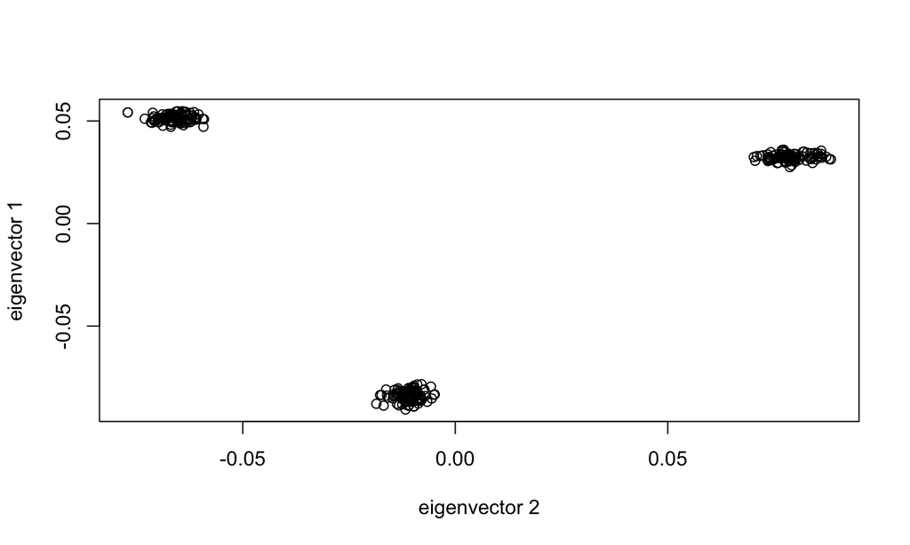

```r
# Draw
plot(tab$EV2, tab$EV1, xlab="eigenvector 2", ylab="eigenvector 1")
```

## PCA on vcf data (part 14)

```r
# Get sample id
sample.id <- read.gdsn(index.gdsn(genofile, "sample.id"))
# Get population information
#   or pop_code <- scan("pop.txt", what=character())
#   if it is stored in a text file "pop.txt"
pop_code <- read.gdsn(index.gdsn(genofile, "sample.annot/pop.group"))
# assume the order of sample IDs is as the same as population codes
head(cbind(sample.id, pop_code))
```

```
##      sample.id pop_code
## [1,] "NA19152" "YRI"
## [2,] "NA19139" "YRI"
## [3,] "NA18912" "YRI"
## [4,] "NA19160" "YRI"
## [5,] "NA07034" "CEU"
## [6,] "NA07055" "CEU"
```

## PCA on vcf data (part 15)

```r
# Make a data.frame
tab <- data.frame(sample.id = pca$sample.id,
    pop = factor(pop_code)[match(pca$sample.id, sample.id)],
    EV1 = pca$eigenvect[,1],    # the first eigenvector
    EV2 = pca$eigenvect[,2],    # the second eigenvector
    stringsAsFactors = FALSE)
head(tab)
```

```
##   sample.id pop         EV1         EV2
## 1   NA19152 YRI -0.08246488 -0.01006984
## 2   NA19139 YRI -0.08225226 -0.01051959
## 3   NA18912 YRI -0.08182177 -0.01274934
## 4   NA19160 YRI -0.08793052 -0.01371887
## 5   NA07034 CEU  0.03160206  0.07831394
## 6   NA07055 CEU  0.03456066  0.08270710
```

## PCA on vcf data (part 16)

```r
# Draw
graphpca <- function() {
plot(tab$EV2, tab$EV1, col=as.integer(tab$pop), xlab="eigenvector 2",
     ylab="eigenvector 1")
legend("bottomright", legend=levels(tab$pop), pch="o",
       col=1:nlevels(tab$pop))
}
```

## PCA on vcf data (part 17)

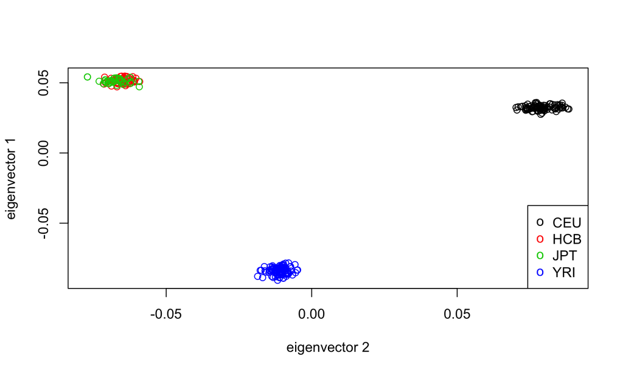

```r
graphpca()
```

## PCA for ancestry

Each principal component represents a direction in the feature space in which the data varies the most. When performing PCA on dense genotyping data these axes of variation represent genetic ancestry.

Recent paper that tries to do this:

http://www.nature.com/ng/journal/v46/n4/full/ng.2924.html

## PCA for ancestry

that introduces the method, LASER, that gets around this problem by estimating ancestry of sequenced individuals using off-target reads without directly calling genotypes.

The LASER algorithm first constructs a PCA map using the the reference panel of individuals. It places each study sample into the reference PCA map one at a time.

It does this by simulating sequence reads for each of the reference individuals to exactly match the coverage of the study sample.

## PCA for ancestry

To construct this second PCA map, LASER uses the pile up counts of non-reference base pairs in the study and (simulated) reference sample reads.

The final step applies Procrustes analysis to transform reference and study sample points from this second PCA into the original PCA space constructed with the reference genotypes.

LASER computes a Procrustes similarity statistic, ranging from 0 to 1, that to compare the mappings between the two PCA spaces for reference samples. The higher this value, the more confident one can be in the placement of the study sample in the reference PCA space.

## PCA for ancestry

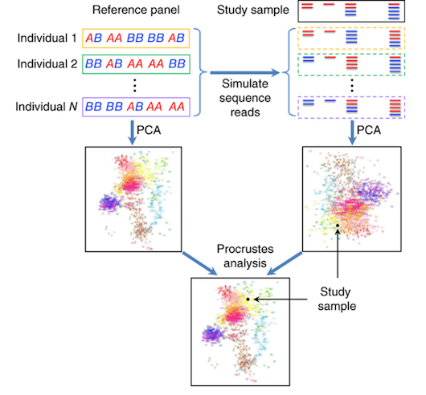

## PCA for ancestry

The authors randomly selected 238 individuals from the HGDP dataset as test samples and the remaining 700 as the reference samples. As the simulated sequence coverage increases, the Procrustes similarity score increases from .950 (.001x) .994 (.01x) .999 (.10x).

## PCA for ancestry

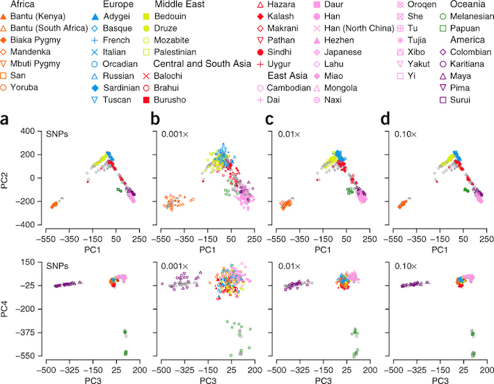

## Diagnostic Tests

Suppose we are interested in two mutually exclusive and exhaustive states of health: -D1 the state that an individual does not have the disease in question -D2 the state of which they have the disease. In this situation the states are complements but this is not neccesarily the case.

## Example

Cerival Cancer is a disease for which the chance of con- tainment is high if detected early. The most common test for this is the Pap Smear. From an onsite proficnecy test was conducted in 1972,1973, and 1978.

This assessed the competency of technicians was scan Pap smearslides. Over- all, 16.25 percent of the tests performed on women with cancer resulted in false negative outcomes.

## Example part 2

So, what this means:

\[ \begin{align} P(test\,negative|cancer) = 0.1625 \\ P(test\,positive|cancer) = 1 - 0.1625 = 0.8375 \end{align} \]

The probability of a positive test result given the individual actually has the disease is called the **sensitivity** of the test.

Not all women tested actually have suffered from cervical cancer. In fact, 18.64% were found from the data to be false positives.

## Example part 3

So, from this we get: \[ \begin{align} P(test\,positive|no\,cancer) = 0.1864 \\ P(test\,negative|cancer) = 1 - 0.1864 = 0.8136 \end{align} \]

The specificity of a test is the probability that its result is negative given that the individual tested does not have the disease. In this study the specificity of the Pap smear was 0.8136

## Note

In genomics we really don't care about the pure number of false positives. In 3 billion basepairs in the human genome you are going to have a lot of errors. A more useful statistic is to look at FP/megabase.

What that means is that I want to know the rate of false positives over 1 million sites on average.

## Example part 4

While sensitivity and specificity is good, often times a clinical test validation report will interested in in the positive predictive value of an approach method or test.

\[ PPV = \frac{No.\, of\, true\, positives}{No.\,of\,true\,positives\,+\,No.\,of\,false\, positives} \] or \[ PPV = \frac{true_positives}{total_positive_calls} \]

What does a PPV of 1 mean?

## Calculate PPV

\[ \begin{align} P(cancer | testPositive) = \frac{P(cancer \intersect testPositive)}{P(testPositive)} \\ =\frac{P(cancer)P(testPositive | cancer)}{P(cancer)P(testPositive|cancer) + P(notCancer)} \end{align} \]